# ExpolarityAnalysis

```python
import numpy as np
import pandas as pd


import seaborn as sns
from scipy.stats import gaussian_kde
import matplotlib.pyplot as plt
sns.set(style="ticks", color_codes=True)
```

```python
BellMRC = pd.read_csv('BellPrepaid_MRC.csv')
BellMRC.head()
```

|  | BAN | SUBS_NO | rDate | Channel | fromPP | toPP | ACCT_TYP | ACCT_SUB_TYP | Num | YR | MTH | StartDate | Qtr |
| --- | --- | --- | --- | --- | --- | --- | --- | --- | --- | --- | --- | --- | --- |
| 0 | 500124386 | 54871967 | 2020-08-05 | Call Center | BF_X | B45ENN | I | P | 1 | 2020 | 8 | 2020-08-02 | 3 |
| 1 | 500208915 | 55537969 | 2020-04-23 | ECARE | BI_X | B07EN | I | P | 1 | 2020 | 4 | 2020-04-19 | 2 |
| 2 | 500223871 | 54880381 | 2020-02-17 | Call Center | BH | B15EN | I | P | 1 | 2020 | 2 | 2020-02-16 | 1 |
| 3 | 500230265 | 56196818 | 2020-02-29 | Call Center | BX_X | B15EN | I | P | 1 | 2020 | 2 | 2020-02-23 | 1 |
| 4 | 500234972 | 55539916 | 2020-01-24 | Call Center | B15DN | B20DN | I | P | 1 | 2020 | 1 | 2020-01-19 | 1 |

```python
LuckyMRC = pd.read_csv('LUCKY_MRC.csv')
LuckyMRC.head()
```

|  | BAN | SUBS_NO | rDate | Channel | fromPP | toPP | ACCT_TYP | ACCT_SUB_TYP | Num | YR | MTH | StartDate | Qtr |
| --- | --- | --- | --- | --- | --- | --- | --- | --- | --- | --- | --- | --- | --- |
| 0 | 539006102 | 24178194 | 2020-09-19 | Call Center | LC50A2 | LC25A3 | I | J | 1 | 2020 | 9 | 2020-09-13 | 3 |
| 1 | 539007006 | 24180662 | 2020-09-16 | ECARE | LC15A1 | LC15A2 | I | J | 1 | 2020 | 9 | 2020-09-13 | 3 |
| 2 | 539007154 | 24180680 | 2020-09-16 | ECARE | LC15A1 | LC25A3 | I | J | 1 | 2020 | 9 | 2020-09-13 | 3 |
| 3 | 539007183 | 24180709 | 2020-09-16 | ECARE | LC15A1 | LC53Q1 | I | J | 1 | 2020 | 9 | 2020-09-13 | 3 |
| 4 | 539008235 | 24181933 | 2020-09-22 | ECARE | LC15A2 | LC15A1 | I | J | 1 | 2020 | 9 | 2020-09-20 | 3 |

```python
MRC = pd.concat([LuckyMRC.assign(Type='Lucky'), BellMRC.assign(Type='Bell')])
MRC.sample(5)
```

|  | BAN | SUBS_NO | rDate | Channel | fromPP | toPP | ACCT_TYP | ACCT_SUB_TYP | Num | YR | MTH | StartDate | Qtr | Type |
| --- | --- | --- | --- | --- | --- | --- | --- | --- | --- | --- | --- | --- | --- | --- |
| 31388 | 537234149 | 21072992 | 2020-02-24 | Call Center | LC50A2 | LC25A3 | I | J | 1 | 2020 | 2 | 2020-02-23 | 1 | Lucky |
| 24461 | 536505379 | 19813043 | 2020-04-08 | Call Center | LC25A3 | LC35A2 | I | J | 1 | 2020 | 4 | 2020-04-05 | 2 | Lucky |
| 40641 | 537418609 | 21364697 | 2020-06-25 | ECARE | LC25A3 | LC40A1 | I | J | 1 | 2020 | 6 | 2020-06-21 | 2 | Lucky |
| 65659 | 533741743 | 14501981 | 2020-08-11 | Call Center | LC15A1 | LC50A2 | I | J | 1 | 2020 | 8 | 2020-08-09 | 3 | Lucky |
| 6276 | 529021034 | 95024447 | 2020-03-28 | ECARE | BPPUA5E | B20EN | I | P | 1 | 2020 | 3 | 2020-03-22 | 1 | Bell |

```python
BellBase = pd.read_excel('BellPrepaid_CustomerBase_CurrentPlans.xlsx')
BellBase = BellBase.loc[:, ~BellBase.columns.str.contains('No column name')]
BellBase.head()
```

|  | SUBSCRIBER_NO | RATE_PLAN | RATE_PLAN_DESC | RATE_PLAN_AMT | BAN_STATUS | SUB_STATUS_DESC | MODEL_CATEGORY | MODEL_TYPE | MODEL_GROUP | MODEL_NAME | PROVINCE_NAME | Region_Group |
| --- | --- | --- | --- | --- | --- | --- | --- | --- | --- | --- | --- | --- |
| 0 | 67032746 | BAW0 | $5.00 - 10 MINUTES | 5.0 | A | Active | Android | Smartphones | Samsung Galaxy S4 16gb | SAMSUNG GS4 WT NR | New Brunswick | Atlantic |
| 1 | 67032805 | BAW0 | $5.00 - 10 MINUTES | 5.0 | A | Active | Handsets | Voice Device | Alcatel Go Flip | ALCATEL GO FLIP 4GB BLACK | Nova Scotia | Atlantic |
| 2 | 67032829 | BAW0T | NICKEL N+W NEW MAIN V5 | 0.0 | A | Active | Handsets | Voice Device | Samsung Sgh-C414m | HSPA SAMSUNG C414M BLACK DEALER | New Brunswick | Atlantic |
| 3 | 67032946 | BAW0Z | NICKEL N+W OLD MAIN V5 | 0.0 | A | Active | Handsets | Voice Device | Alcatel Go Flip | ALCATEL GO FLIP 4GB BLACK | Prince Edward | Atlantic |
| 4 | 67033047 | BAW0Z | NICKEL N+W OLD MAIN V5 | 0.0 | A | Active | Apple Iphone | Smartphones | Apple Iphone 4s 16gb | HSPA APP IPHONE4S 16GB W DEALER | Nova Scotia | Atlantic |

```python
LuckyBase = pd.read_excel('Lucky_CustomerBase_CurrentPlans.xlsx')
LuckyBase = LuckyBase.loc[:, ~LuckyBase.columns.str.contains('No column name')]
LuckyBase.head()
```

|  | SUBSCRIBER_NO | RATE_PLAN | RATE_PLAN_DESC | RATE_PLAN_AMT | BAN_STATUS | SUB_STATUS_DESC | MODEL_CATEGORY | MODEL_TYPE | MODEL_GROUP | MODEL_NAME | PROVINCE_NAME | Region_Group |
| --- | --- | --- | --- | --- | --- | --- | --- | --- | --- | --- | --- | --- |
| 0 | 98493722 | LC35A1 | $35 ULTD CANADA PLAN | 35 | A | Active | Apple Iphone | Smartphones | Apple Iphone 6 32gb | APPLE IPHONE 6 32GB GREY | Alberta | Western Region |
| 1 | 98493884 | LC10A1 | $10 CANADA 50 MINUTE PLAN | 10 | A | Active | Sim-Only | Other | Blu Products Inc Blu Vivo One Plus | BLU VIVO ONE PLUS | Ontario | Central Region |
| 2 | 98493900 | LC40A1 | $40 ULTD CANADA PLAN - 4GB | 40 | A | Active | Sim-Only | Other | Samsung Korea Samsung Sm-N950w | SAMSUNG SM-N950W | Ontario | Central Region |
| 3 | 98494112 | LC50A2 | $50 ULTD CANADA PLAN - 6GB | 50 | A | Active | Android | Smartphones | Samsung Galaxy S4 16gb | SAMSUNG GS4 BK NR | British Columbia | Western Region |
| 4 | 98494340 | LC25A3 | $25 ULTD CANADA PLAN | 25 | A | Active | Android | Smartphones | Samsung Galaxy S7 | SAMSUNG SM-G930F | Ontario | Central Region |

```python
CustBase = pd.concat([LuckyBase.assign(Type='Lucky'), BellBase.assign(Type='Bell')])
CustBase.sample(5)
```

|  | SUBSCRIBER_NO | RATE_PLAN | RATE_PLAN_DESC | RATE_PLAN_AMT | BAN_STATUS | SUB_STATUS_DESC | MODEL_CATEGORY | MODEL_TYPE | MODEL_GROUP | MODEL_NAME | PROVINCE_NAME | Region_Group | Type |
| --- | --- | --- | --- | --- | --- | --- | --- | --- | --- | --- | --- | --- | --- |
| 134768 | 11395932 | B30EN | $30 - 250 MIN - 250MB | 30.0 | A | Active | Apple Iphone | Smartphones | Apple Iphone Se 32gb | APPLE IPH SE 32GB GREY | Ontario | Central Region | Bell |
| 171139 | 21699652 | LC15A2 | $15 CANADA 100 MINUTE PLAN | 15.0 | A | Active | Sim-Only | Other | Motorola Mobility Llc, A Lenovo Company Rb1243... | RB12430945 | Quebec | Central Region | Lucky |
| 300771 | 19427208 | LC25A3 | $25 ULTD CANADA PLAN | 25.0 | A | Active | Sim-Only | Other | Unmapped Greymarket | HONOR 8X | Manitoba | Western Region | Lucky |
| 178744 | 18240502 | LC50A2 | $50 ULTD CANADA PLAN - 6GB | 50.0 | A | Active | Android | Smartphones | Lg M151 | LG-M151 | Alberta | Western Region | Lucky |
| 14343 | 19711174 | LC25A3 | $25 ULTD CANADA PLAN | 25.0 | A | Active | Apple Iphone | Smartphones | Apple Inc Iphone 6s | APPLE IPHONE 6S (A1688) | Nova Scotia | Atlantic | Lucky |

```python
CustBase.groupby('Type')['RATE_PLAN_AMT'].agg(lambda x: np.mean(x<=75))
```

```
Type
Bell     0.999965
Lucky    1.000000
Name: RATE_PLAN_AMT, dtype: float64
```

As we can see from above table:

- More than 99.99% Bell User have Plan of 75 and below
- All Lucky User have plan of less than of equal to 75

We will not consider any plan cost more than 75, because this will gives better vizualization without effecting the distribution much

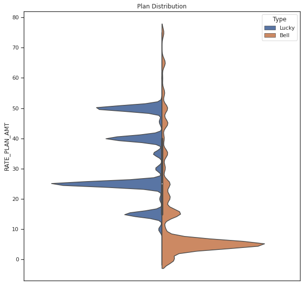

```python
plans_dist2 = CustBase.query('RATE_PLAN_AMT <= 75')

fig, ax = plt.subplots(figsize=(10, 10))
sns.violinplot(x=plans_dist2['RATE_PLAN_AMT']*0, hue=plans_dist2['Type'], y=plans_dist2['RATE_PLAN_AMT'], split=True, ax=ax)
ax.set_xticks([])
ax.set_xlabel('')
ax.set_ylabel('RATE_PLAN_AMT')
ax.set_title('Plan Distribution');
```

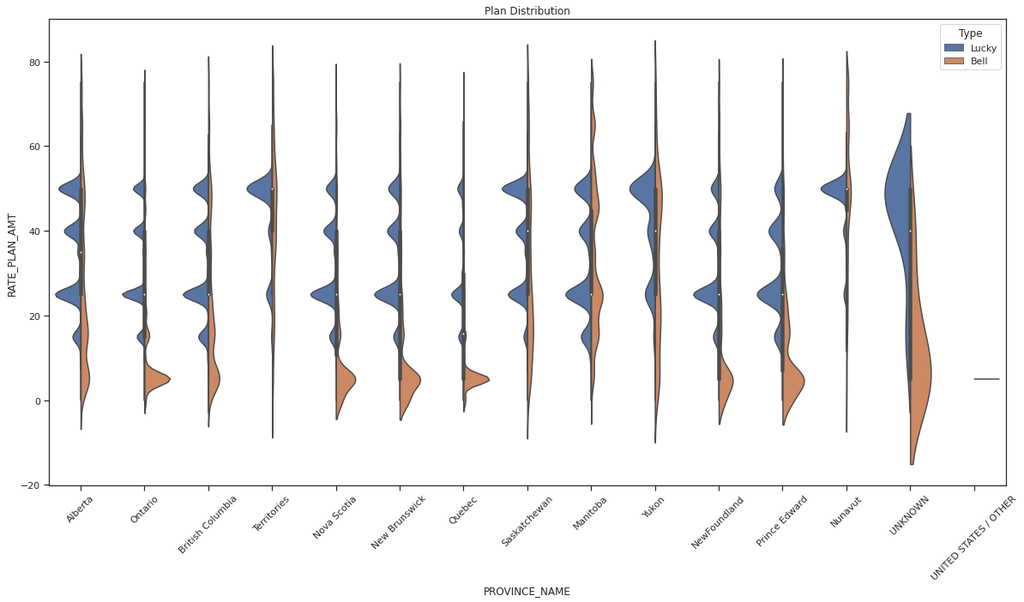

```python
fig, ax = plt.subplots(figsize=(20, 10))
sns.violinplot(x=plans_dist2['PROVINCE_NAME'], hue=plans_dist2['Type'], y=plans_dist2['RATE_PLAN_AMT'], split=True, ax=ax)
plt.xticks(rotation=45)
ax.set_xlabel('PROVINCE_NAME')
ax.set_ylabel('RATE_PLAN_AMT')
ax.set_title('Plan Distribution');
```

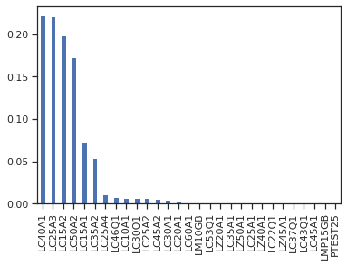

```python
lucky_fromPP_dist = LuckyMRC['fromPP'].value_counts(normalize=True)
lucky_fromPP_dist.plot.bar()
```

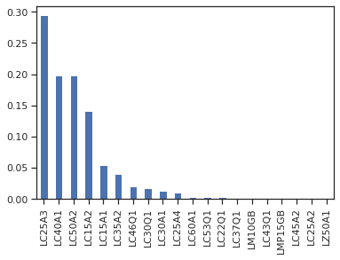

```python
lucky_toPP_dist = LuckyMRC['toPP'].value_counts(normalize=True)
lucky_toPP_dist.plot.bar()
```

```python
np.sum(lucky_fromPP_dist.iloc[:10])
```

```
0.9718682035667681
```

```python
np.sum(lucky_toPP_dist.iloc[:10])
```

```
0.9860047846889952
```

Top 10 fromPP capture 97.1% observation, and Top 10 toPP capture 98.6% observations. So we will plot the data for only pp who are either in top10 fromPP or top10 toPP

```python
lucky_top_fromPP = lucky_fromPP_dist.iloc[:10].index.values
lucky_top_toPP = lucky_toPP_dist.iloc[:10].index.values

lucky_top_PP = pd.Series(np.unique(np.r_[lucky_top_fromPP, lucky_top_toPP]))
lucky_top_PP
```

```
0     LC10A1
1     LC15A1
2     LC15A2
3     LC25A3
4     LC25A4
5     LC30A1
6     LC30Q1
7     LC35A2
8     LC40A1
9     LC46Q1
10    LC50A2
dtype: object
```

```python
pp_dist = pd.concat([lucky_fromPP_dist.reindex(lucky_top_PP).fillna(0).rename('Density').reset_index().assign(Type = 'from'),
                     lucky_toPP_dist.reindex(lucky_top_PP).fillna(0).rename('Density').reset_index().assign(Type = 'to')])\
    .rename(columns={'index': 'PP'})

pp_dist.groupby('Type')['Density'].sum()
```

```
Type
from    0.976370
to      0.986005
Name: Density, dtype: float64
```

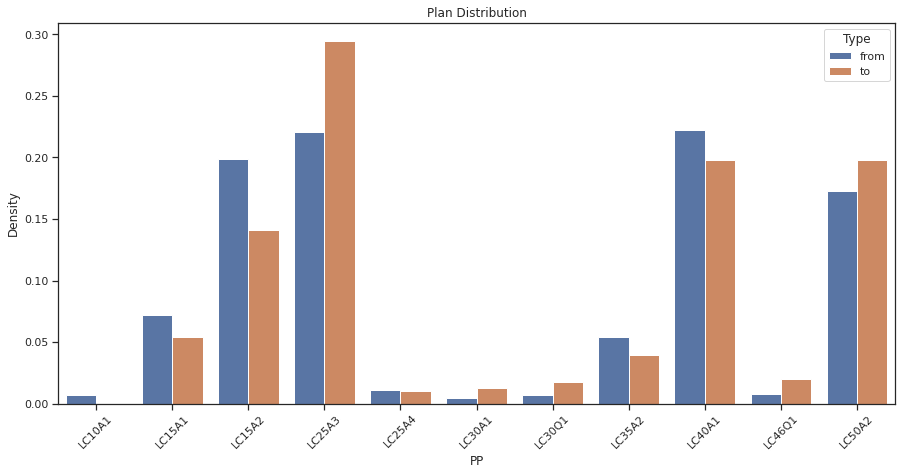

```python
fig, ax = plt.subplots(figsize=(15, 7))
sns.barplot(data=pp_dist, x='PP', y='Density', hue='Type', ax=ax)
plt.xticks(rotation=45)
ax.set_title('Plan Distribution');
```

The selected top 11 PP (union of top 10 fromPP and top10 toPP) capture 97.6% fromPP observation and 98.6% toPP Observation.

Although the cumulative market share is almost same. But we can observe movement withPP.

Now, on the below diagram we will analyze the movement within these 11 PP.

```python
lucky_movement = LuckyMRC.query('fromPP in @lucky_top_PP and toPP in @lucky_top_PP')[['fromPP', 'toPP']].value_counts().rename('count').reset_index()
lucky_movement = lucky_movement.query('fromPP != toPP').sort_values(by=['fromPP', 'toPP'])
lucky_movement
```

|  | fromPP | toPP | count |
| --- | --- | --- | --- |
| 73 | LC10A1 | LC15A1 | 35 |
| 34 | LC10A1 | LC15A2 | 326 |
| 45 | LC10A1 | LC25A3 | 186 |
| 89 | LC10A1 | LC25A4 | 11 |
| 90 | LC10A1 | LC30A1 | 11 |
| ... | ... | ... | ... |
| 50 | LC50A2 | LC30A1 | 156 |
| 44 | LC50A2 | LC30Q1 | 187 |
| 24 | LC50A2 | LC35A2 | 844 |
| 2 | LC50A2 | LC40A1 | 6710 |
| 28 | LC50A2 | LC46Q1 | 502 |

97 rows × 3 columns

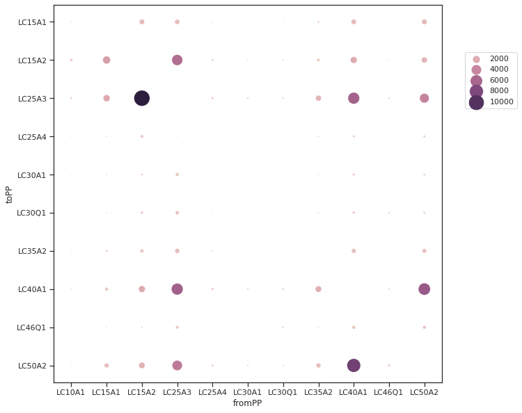

```python
fig, ax = plt.subplots(figsize=(10, 10))
g = sns.scatterplot(data=lucky_movement, sizes=(1, 500), x='fromPP', y='toPP', hue='count', size='count', s=500, ax=ax)
g.legend(loc='center left', bbox_to_anchor=(1.05, 0.8), ncol=1);
```

```
Month: 1
from: 96.32%
to: 99.43%
```

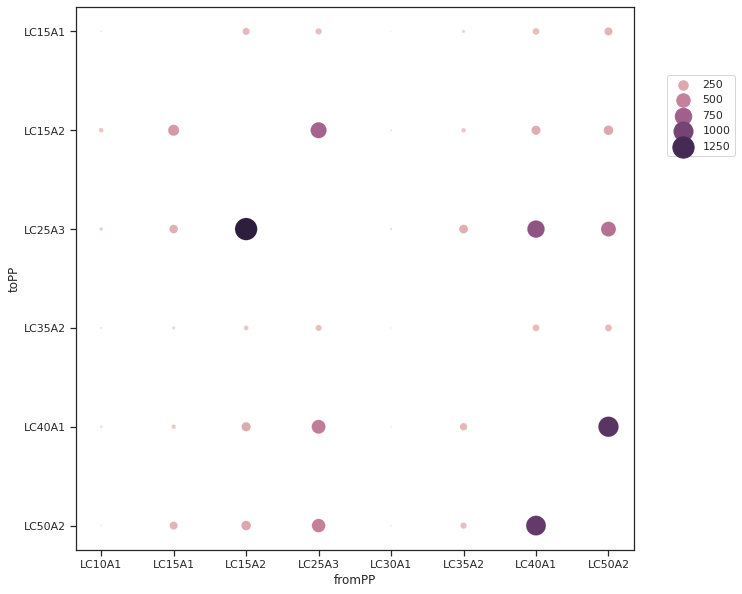

```
Month: 2
from: 97.16%
to: 99.79%
```

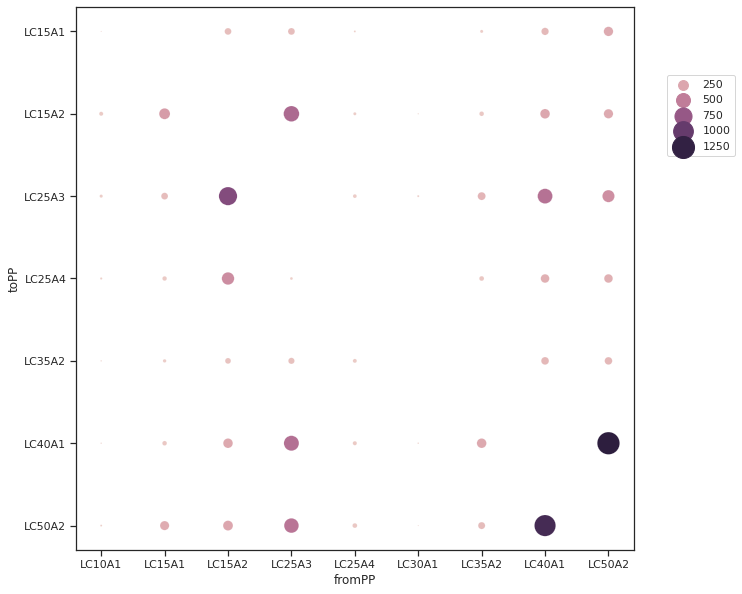

```
Month: 3
from: 97.48%
to: 99.50%
```

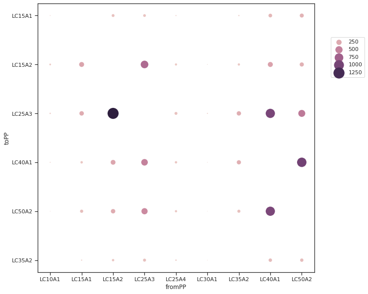

```
Month: 4
from: 98.34%
to: 99.99%
```

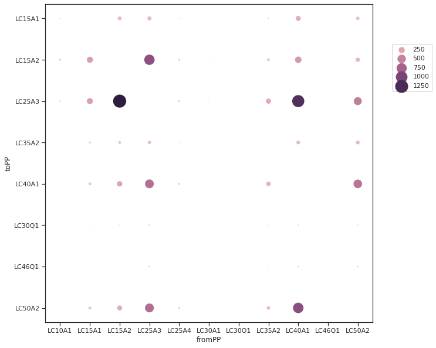

```
Month: 5
from: 98.15%
to: 96.78%
```

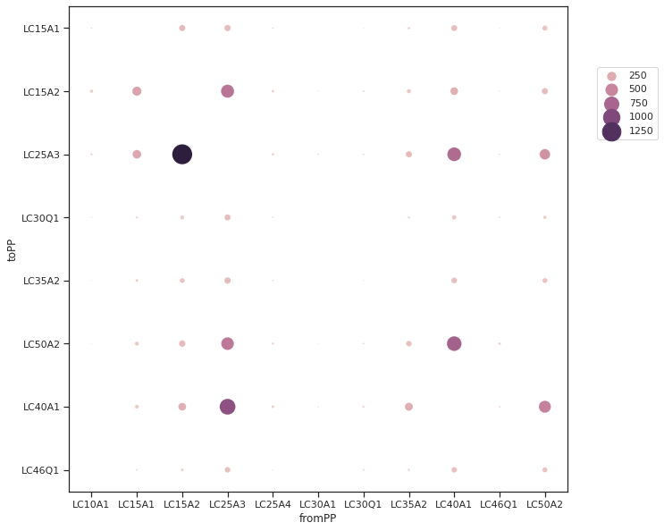

```
Month: 6
from: 97.77%
to: 99.98%
```

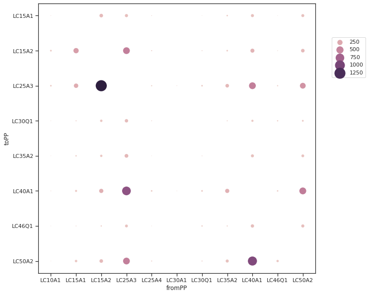

```
Month: 7
from: 98.46%
to: 100.00%
```

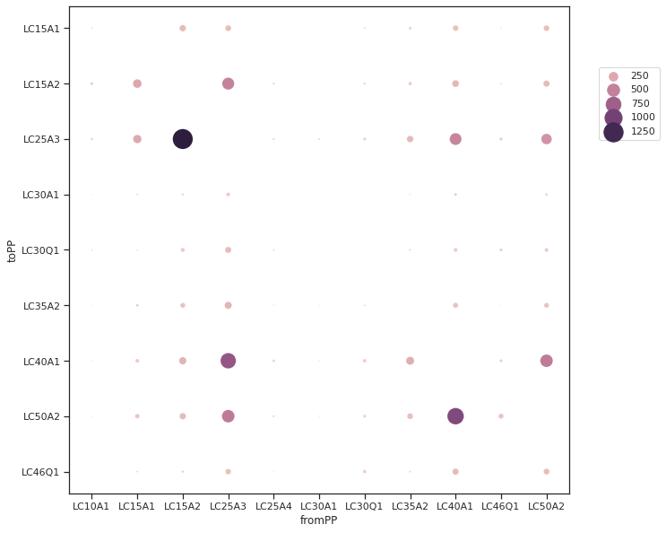

```
Month: 8
from: 98.20%
to: 97.70%
```

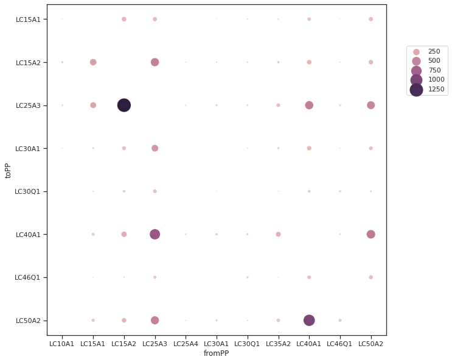

```
Month: 9
from: 96.80%
to: 93.40%
```

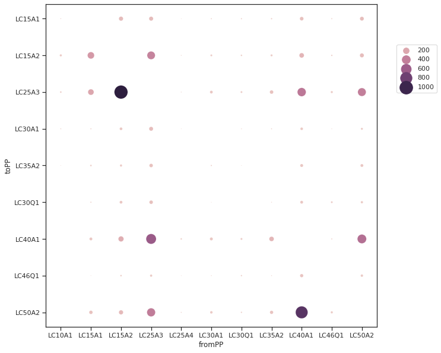

```python
### Month Loop
for m in np.unique(LuckyMRC['MTH']):
    LuckyMRC_Month = LuckyMRC.query('MTH == @m')
    from_portion = LuckyMRC_Month.query('fromPP in @lucky_top_PP').shape[0]/LuckyMRC_Month.shape[0]
    to_portion = LuckyMRC_Month.query('toPP in @lucky_top_PP').shape[0]/LuckyMRC_Month.shape[0]

    print(f'\n\nMonth: {m}')
    print(f'from: {from_portion:0.2%}')
    print(f'to: {to_portion:0.2%}')

    lucky_movement_month = LuckyMRC_Month.query('fromPP in @lucky_top_PP and toPP in @lucky_top_PP')[['fromPP', 'toPP']].value_counts().rename('count').reset_index()
    lucky_movement_month = lucky_movement_month.query('fromPP != toPP').sort_values(by=['fromPP', 'toPP'])

    fig, ax = plt.subplots(figsize=(10, 10))
    g = sns.scatterplot(data=lucky_movement_month, sizes=(1, 500), x='fromPP', y='toPP', hue='count', size='count', s=500, ax=ax)
    g.legend(loc='center left', bbox_to_anchor=(1.05, 0.8), ncol=1)
    plt.show()
```

## Another Visualization Startegy for Lucky

```python
lucky_movement = LuckyMRC[['fromPP', 'toPP']].value_counts().rename('count').reset_index()
lucky_movement = lucky_movement.query('fromPP != toPP').sort_values(by=['fromPP', 'toPP'])
lucky_movement
```

|  | fromPP | toPP | count |
| --- | --- | --- | --- |
| 98 | LC10A1 | LC15A1 | 35 |
| 34 | LC10A1 | LC15A2 | 326 |
| 207 | LC10A1 | LC22Q1 | 4 |
| 47 | LC10A1 | LC25A3 | 186 |
| 151 | LC10A1 | LC25A4 | 11 |
| ... | ... | ... | ... |
| 220 | LZ50A1 | LC35A2 | 3 |
| 147 | LZ50A1 | LC40A1 | 11 |
| 95 | LZ50A1 | LC50A2 | 36 |
| 262 | LZ50A1 | LC60A1 | 1 |
| 296 | PTEST25 | LC15A2 | 1 |

286 rows × 3 columns

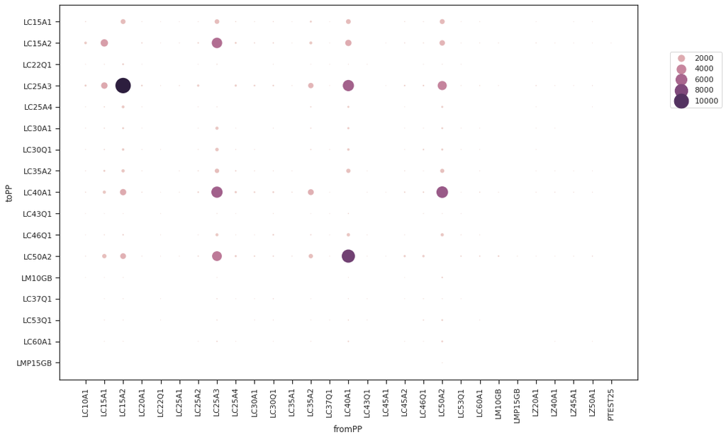

```python
fig, ax = plt.subplots(figsize=(15, 10))
g = sns.scatterplot(data=lucky_movement, sizes=(1, 500), x='fromPP', y='toPP', hue='count', size='count', s=500, ax=ax)
plt.xticks(rotation=90)
g.legend(loc='center left', bbox_to_anchor=(1.05, 0.8), ncol=1);
```

```
Month: 1
```

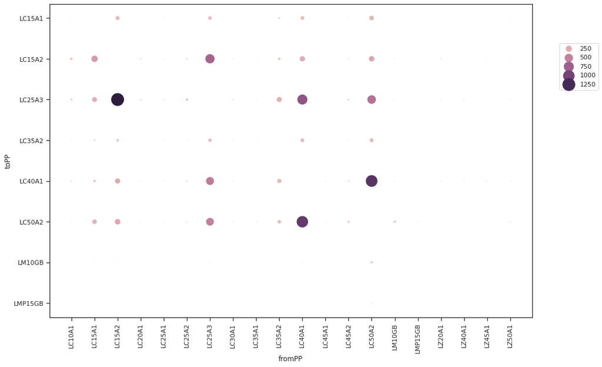

```
Month: 2
```

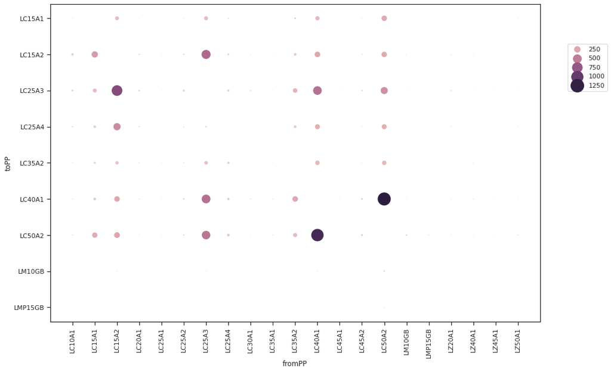

```
Month: 3
```

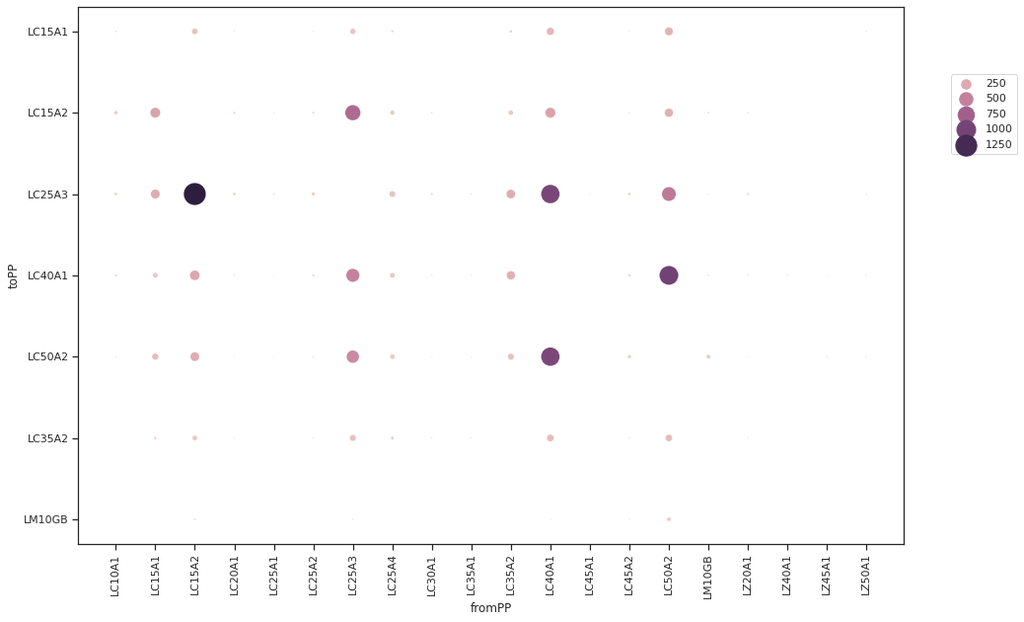

```
Month: 4
```

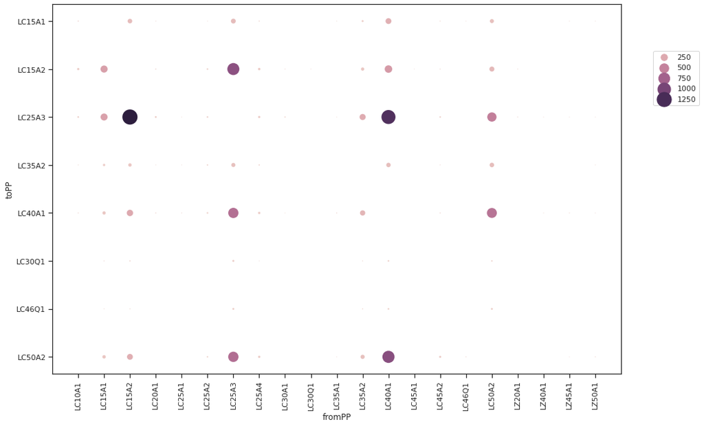

```
Month: 5
```

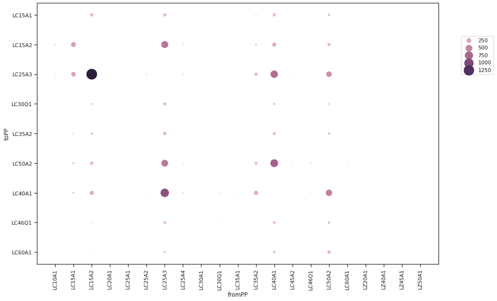

```
Month: 6
```

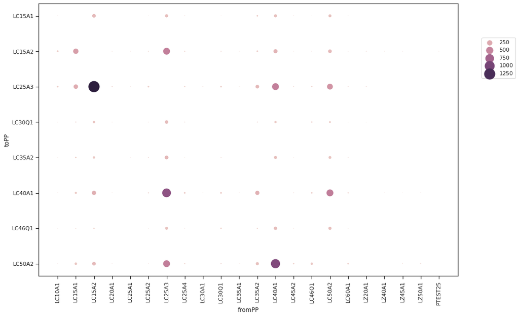

```
Month: 7
```

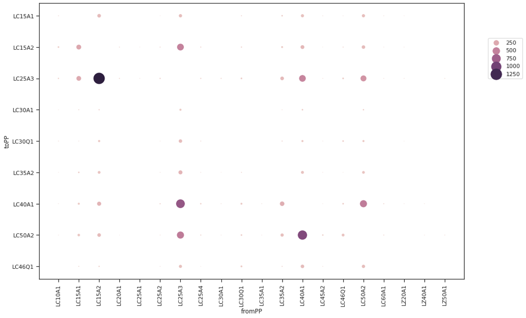

```
Month: 8
```

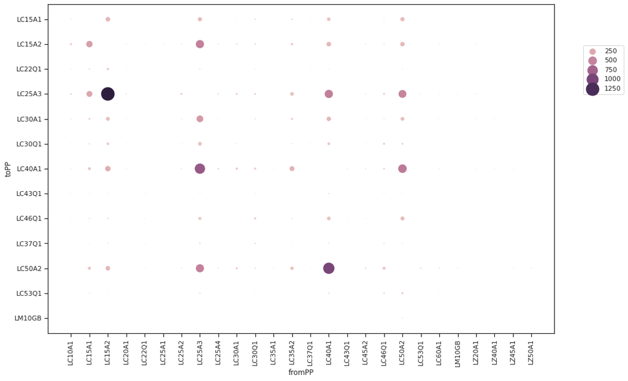

```
Month: 9
```

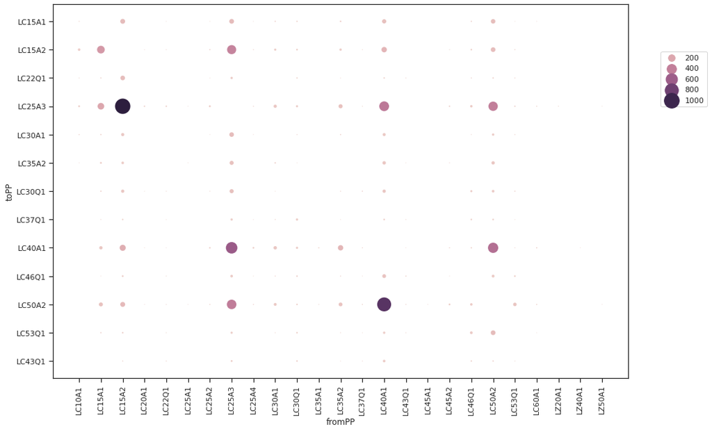

```python
### Month Loop
for m in np.unique(LuckyMRC['MTH']):
    LuckyMRC_month = LuckyMRC.query('MTH == @m')

    lucky_movement_month = LuckyMRC_month[['fromPP', 'toPP']].value_counts().rename('count').reset_index()
    lucky_movement_month = lucky_movement_month.query('fromPP != toPP').sort_values(by=['fromPP', 'toPP'])

    print(f'\n\nMonth: {m}')

    fig, ax = plt.subplots(figsize=(15, 10))
    g = sns.scatterplot(data=lucky_movement_month, sizes=(1, 500), x='fromPP', y='toPP', hue='count', size='count', s=500, ax=ax)
    plt.xticks(rotation=90)
    g.legend(loc='center left', bbox_to_anchor=(1.05, 0.8), ncol=1)
    plt.show();
```

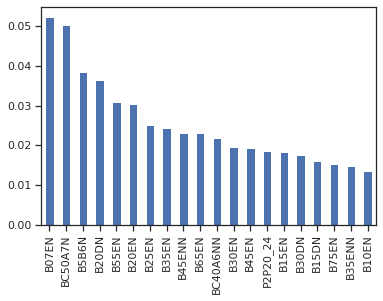

```python
bell_fromPP_dist = BellMRC['fromPP'].value_counts(normalize=True)
bell_fromPP_dist.iloc[:20].plot.bar()
```

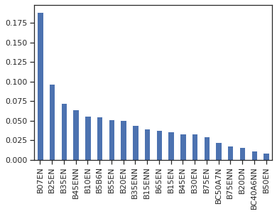

```python
bell_toPP_dist = BellMRC['toPP'].value_counts(normalize=True)
bell_toPP_dist.iloc[:20].plot.bar()
```

```python
bell_fromPP_dist.shape
```

```
(1257,)
```

```python
np.sum(bell_fromPP_dist.iloc[:50])
```

```
0.6864291717850908
```

```python
bell_toPP_dist.shape
```

```
(42,)
```

```python
np.sum(bell_toPP_dist.iloc[:20])
```

```
0.9662507273550138
```

Top 50 fromPP capture 68.6% observation, and Top 20 toPP capture 96.6% observations. So we will plot the data for only pp who are either in top50 fromPP or top20 toPP and going with more PP will not provide visual insight.

```python
bell_top_fromPP = bell_fromPP_dist.iloc[:50].index.values
bell_top_toPP = bell_toPP_dist.iloc[:20].index.values

bell_top_PP = pd.Series(np.unique(np.r_[bell_top_fromPP, bell_top_toPP]))
bell_top_PP
```

```
0         B07EN
1         B10EN
2         B15A1
3         B15A3
4        B15A5E
5        B15A6N
6        B15C6N
7        B15D6N
8         B15DN
9         B15EN
10       B15ENN
11       B20A5E
12        B20DN
13        B20EN
14       B22A6N
```

[output cut: 37 more lines]

```python
pp_dist = pd.concat([bell_fromPP_dist.reindex(bell_top_PP).fillna(0).rename('Density').reset_index().assign(Type = 'from'),
                     bell_toPP_dist.reindex(bell_top_PP).fillna(0).rename('Density').reset_index().assign(Type = 'to')])\
    .rename(columns={'index': 'PP'})

pp_dist.groupby('Type')['Density'].sum()
```

```
Type
from    0.68908
to      0.98513
Name: Density, dtype: float64
```

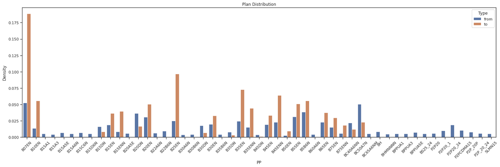

```python
fig, ax = plt.subplots(figsize=(25, 7))
sns.barplot(data=pp_dist, x='PP', y='Density', hue='Type', ax=ax)
plt.xticks(rotation=45)
ax.set_title('Plan Distribution');
```

No will draw to scatter plot for top Movements

```python
bell_movement = BellMRC[['fromPP', 'toPP']].value_counts().rename('count').reset_index()
bell_movement = bell_movement.query('fromPP != toPP').sort_values(by=['fromPP', 'toPP'])
bell_movement
```

|  | fromPP | toPP | count |
| --- | --- | --- | --- |
| 1255 | 8TKM_36_V | B07EN | 2 |
| 1533 | AC90124AB | B07EN | 1 |
| 1537 | AH10_36_V | B07EN | 1 |
| 1538 | ALIN25_36 | B07EN | 1 |
| 1541 | ALIN30N36 | B07EN | 1 |
| ... | ... | ... | ... |
| 2347 | ZPNW6524 | B35EN | 1 |
| 2346 | ZSNS50P24 | B07EN | 1 |
| 2345 | ZSNS50P24 | B5B6N | 1 |
| 2728 | ZSPLC5524 | B07EN | 1 |
| 1914 | ZSPNW6024 | B25EN | 1 |

3196 rows × 3 columns

```python
bell_movement['count'].sum()
```

```
15430
```

There is movement of 15430. So will draw the scatter plot for those PP movment which capture at least 0.1%

```python
movement_cutoff = 0.001*15430
print(movement_cutoff)
bell_movement_sub = bell_movement.query('count >= @movement_cutoff')
bell_movement_sub
```

```
15.43
```

|  | fromPP | toPP | count |
| --- | --- | --- | --- |
| 96 | B07EN | B10EN | 31 |
| 5 | B07EN | B15EN | 115 |
| 55 | B07EN | B15ENN | 44 |
| 4 | B07EN | B20EN | 117 |
| 1 | B07EN | B25EN | 134 |
| ... | ... | ... | ... |
| 159 | P2P_20P | B5B6N | 22 |
| 45 | P2P_20_24 | B07EN | 50 |
| 123 | P2P_20_24 | B5B6N | 26 |
| 107 | SLMN15 | B07EN | 28 |
| 124 | SLMN15 | B15ENN | 26 |

221 rows × 3 columns

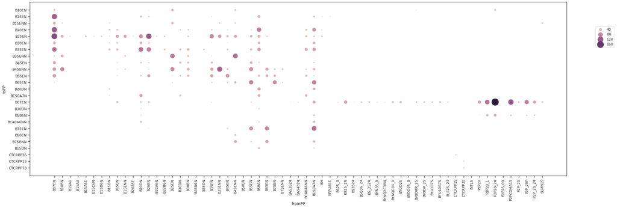

```python
fig, ax = plt.subplots(figsize=(30, 10))
g = sns.scatterplot(data=bell_movement_sub, sizes=(1, 500), x='fromPP', y='toPP', hue='count', size='count', s=500, ax=ax)
plt.xticks(rotation=90)
g.legend(loc='center left', bbox_to_anchor=(1.05, 0.8), ncol=1);
```